# BAYESIAN INDEX MODELS FOR HETEROGENEOUS TREATMENT EFFECTS

5

nonlinear

linear

0.4291610

0.4226195

0.0065415

0.5247154

0.4756302

1.315606

0.8908

0.5957

0.4766813

1.339203

0.0540618

28

8

1000

5

nonlinear

linear

0.746

0.4376924

0.4242768

0.0134156

0.5268912

0.4757308

1.326695

0.8147

0.5707

0.4816714

1.348410

0.0573946

32

8

60

1000

5

nonlinear

linear

0.687

0.4376676

0.4237221

0.0139454

0.5271820

0.4756865

1.315096

0.8475

0.7351

0.4569590

1.331403

0.0332368

29

8

61

1000

5

nonlinear

linear

0.696

0.4431413

0.4240082

0.0191331

0.5278947

0.4755675

1.330002

0.7966

0.6532

0.4691917

1.356298

0.0451836

26

8

62

1000

5

nonlinear

linear

0.597

0.4423581

0.4221750

0.0201831

0.5248514

0.4759406

1.322553

0.8197

0.5714

0.4798017

1.350691

0.0576267

25

8. n=1000, p= 5, g.choice=nonlinear, m.choice=linear

8

63

1000

5

nonlinear

linear

0.719

0.4539573

0.4236651

0.0302922

0.5270241

0.4751647

1.331091

0.7399

0.5523

0.4831007

1.331778

0.0594357

33

8. n=1000, p= 5, g.choice=nonlinear, m.choice=linear

8

64

1000

5

nonlinear

linear

0.632

0.4558200

0.4217071

0.0341129

0.5250117

0.4744423

1.332071

0.6982

0.5736

0.4746962

1.346626

0.0529891

35

8. n=1000, p= 5, g.choice=nonlinear, m.choice=linear

8

65

1000

5

nonlinear

linear

0.704

0.4500378

0.4230028

0.0270351

0.5245294

0.4765626

1.330943

0.7521

0.6928

0.4624992

1.338982

0.0394964

30

8. n=1000, p= 5, g.choice=nonlinear, m.choice=linear

8

66

1000

5

nonlinear

linear

0.654

0.4270876

0.4248915

0.0021961

0.5257536

0.4778419

1.313371

0.9369

0.5738

0.4815223

1.338011

0.0566308

27

8. n=1000, p= 5, g.choice=nonlinear, m.choice=linear

8

67

1000

5

nonlinear

linear

0.715

0.4372736

0.4242875

0.0129861

0.5252353

0.4779733

1.318337

0.8384

0.5819

0.4822967

1.348167

0.0580092

28

8. n=1000, p= 5, g.choice=nonlinear, m.choice=linear

8

68

1000

5

nonlinear

linear

0.706

0.4316134

0.4236522

0.0079613

0.5264181

0.4758570

1.328306

0.8834

0.5502

0.4844445

1.357350

0.0607923

33

8. n=1000, p= 5, g.choice=nonlinear, m.choice=linear

8

69

1000

5

nonlinear

linear

0.722

0.4364049

0.4220848

0.0143201

0.5274973

0.4733484

1.321241

0.8344

0.5626

0.4803073

1.343858

0.0582225

28

8. n=1000, p= 5, g.choice=nonlinear, m.choice=linear

8

70

1000

5

nonlinear

linear

0.739

0.4359488

0.4204707

0.0154781

0.5229650

0.4732023

1.316380

0.8289

0.5592

0.4794990

1.334923

0.0590283

24

8. n=1000, p= 5, g.choice=nonlinear, m.choice=linear

8

71

1000

5

nonlinear

linear

0.489

0.4936678

0.4228876

0.0707801

0.5260810

0.4749412

1.351327

0.5247

0.6217

0.4724965

1.346908

0.0496089

28

8. n=1000, p= 5, g.choice=nonlinear, m.choice=linear

8

72

1000

5

nonlinear

linear

0.708

0.4435058

0.4228695

0.0206362

0.5238339

0.4768516

1.324766

0.7920

0.6247

0.4727299

1.346579

0.0498604

24

8. n=1000, p= 5, g.choice=nonlinear, m.choice=linear

8

73

1000

5

nonlinear

linear

0.648

0.4498678

0.4217475

0.0281204

0.5249140

0.4733447

1.331491

0.7567

0.5774

0.4826712

1.352212

0.0609237

26

8. n=1000, p= 5, g.choice=nonlinear, m.choice=linear

8

74

1000

5

nonlinear

linear

0.668

0.4295441

0.4218424

0.0077018

0.5246552

0.4745091

1.309664

0.8836

0.5756

0.4814834

1.344448

0.0596411

28

8. n=1000, p= 5, g.choice=nonlinear, m.choice=linear

8

75

1000

5

nonlinear

linear

0.680

0.4591769

0.4239815

0.0351953

0.5264057

0.4761517

1.338343

0.6989

0.5627

0.4816780

1.342355

0.0576965

33

8. n=1000, p= 5, g.choice=nonlinear, m.choice=linear

8

76

1000

5

nonlinear

linear

0.568

0.4507871

0.4218212

0.0289659

0.5235543

0.4748748

1.326876

0.7335

0.6757

0.4630784

1.344360

0.0412572

32

8. n=1000, p= 5, g.choice=nonlinear, m.choice=linear

8

77

1000

5

nonlinear

linear

0.697

0.4650097

0.4235845

0.0414252

0.5264178

0.4761236

1.327662

0.6914

0.6489

0.4696978

1.333822

0.0461133

31

8. n=1000, p= 5, g.choice=nonlinear, m.choice=linear

8

78

1000

5

nonlinear

linear

0.705

0.4365476

0.4224628

0.0140848

0.5257004

0.4751735

1.321573

0.8312

0.5568

0.4808186

1.340870

0.0583558

27

8. n=1000, p= 5, g.choice=nonlinear, m.choice=linear

8

79

1000

5

nonlinear

linear

0.655

0.4373645

0.4240411

0.0133234

0.5266795

0.4768952

1.318912

0.8394

0.5498

0.4844987

1.331125

0.0604577

26

8. n=1000, p= 5, g.choice=nonlinear, m.choice=linear

8

1000

5

nonlinear

linear

0.761

0.4435958

0.4249412

0.0186546

0.5267688

0.4778396

1.334137

0.7962

0.5872

0.4796162

1.356729

0.0546749

32

8. n=1000, p= 5, g.choice=nonlinear, m.choice=linear

8

81

1000

5

nonlinear

linear

0.679

0.4458642

0.4239232

0.0219410

0.5249954

0.4783822

1.335647

0.7912

0.6104

0.4791700

1.351296

0.0552468

29

8. n=1000, p= 5, g.choice=nonlinear, m.choice=linear

8

82

1000

5

nonlinear

linear

0.695

0.4321352

0.4215347

0.0106005

0.5248076

0.4737964

1.324323

0.8578

0.5575

0.4806459

1.351239

0.0591112

38

8. n=1000, p= 5, g.choice=nonlinear, m.choice=linear

8

83

1000

5

nonlinear

linear

0.662

0.4324442

0.4219490

0.0104952

0.5247457

0.4751332

1.319856

0.8599

0.5535

0.4818497

1.338246

0.0599007

28

8. n=1000, p= 5, g.choice=nonlinear, m.choice=linear

8

84

1000

5

nonlinear

linear

0.752

0.4435421

0.4244894

0.0190527

0.5271463

0.4771361

1.332451

0.8046

0.5935

0.4824772

1.355309

0.0579878

24

8. n=1000, p= 5, g.choice=nonlinear, m.choice=linear

8

85

1000

5

nonlinear

linear

0.705

0.4479394

0.4235275

0.0244119

0.5258331

0.4761609

1.336780

0.7639

0.6147

0.4748675

1.347409

0.0513400

25

8. n=1000, p= 5, g.choice=nonlinear, m.choice=linear

8

86

1000

5

nonlinear

linear

0.629

0.4514553

0.4239258

0.0275295

0.5243625

0.4777038

1.333474

0.7409

0.5520

0.4841709

1.340310

0.0602451

26

8. n=1000, p= 5, g.choice=nonlinear, m.choice=linear

8

87

1000

5

nonlinear

linear

0.670

0.4812672

0.4228851

0.0583821

0.5243053

0.4767840

1.343346

0.5888

0.5826

0.4814294

1.347296

0.0585444

26

8. n=1000, p= 5, g.choice=nonlinear, m.choice=linear

8

88

1000

5

nonlinear

linear

0.715

0.4425651

0.4229564

0.0196087

0.5257069

0.4749379

1.315225

0.7911

0.5811

0.4787793

1.340140

0.0558229

31

8. n=1000, p= 5, g.choice=nonlinear, m.choice=linear

8

89

1000

5

nonlinear

linear

0.636

0.4373189

0.4239542

0.0133647

0.5274103

0.4770143

1.322222

0.8454

0.6432

0.4718033

1.351644

0.0478491

30

8. n=1000, p= 5, g.choice=nonlinear, m.choice=linear

8

90

1000

5

nonlinear

linear

0.682

0.4476995

0.4207301

0.0269694

0.5248620

0.4728081

1.318031

0.7503

0.6706

0.4640451

1.338440

0.0433150

27

8. n=1000, p= 5, g.choice=nonlinear, m.choice=linear

8

91

1000

5

nonlinear

linear

0.643

0.4395480

0.4238900

0.0156580

0.5255725

0.4767809

1.321377

0.8260

0.5737

0.4841595

1.337924

0.0602694

31

8. n=1000, p= 5, g.choice=nonlinear, m.choice=linear

8

92

1000

5

nonlinear

linear

0.679

0.4600641

0.4223611

0.0377030

0.5242327

0.4753386

1.323479

0.6739

0.5512

0.4828188

1.346433

0.0604577

32

8. n=1000, p= 5, g.choice=nonlinear, m.choice=linear

8

93

1000

5

nonlinear

linear

0.730

0.4368830

0.4226407

0.0142423

0.5240498

0.4761372

1.323867

0.8429

0.7145

0.4586239

1.338862

0.0359833

31

8. n=1000, p= 5, g.choice=nonlinear, m.choice=linear

8

94

1000

5

nonlinear

linear

0.694

0.4442928

0.4201193

0.0241735

0.5252122

0.4716979

1.336501

0.7767

0.6087

0.4745033

1.350918

0.0543840

30

8. n=1000, p= 5, g.choice=nonlinear, m.choice=linear

8

95

1000

5

nonlinear

linear

0.688

0.4317826

0.4229807

0.0088020

0.5242126

0.4763053

1.324183

0.8734

0.5632

0.4850486

1.342945

0.0620679

25

8. n=1000, p= 5, g.choice=nonlinear, m.choice=linear

8

96

1000

5

nonlinear

linear

0.696

0.4315882

0.4242291

0.0073591

0.5264906

0.4774698

1.316776

0.8959

0.6732

0.4673309

1.342467

0.0431018

32

8. n=1000, p= 5, g.choice=nonlinear, m.choice=linear

8

97

1000

5

nonlinear

linear

0.720

0.4334584

0.4262279

0.0072305

0.5278529

0.4781064

1.327537

0.8858

0.5511

0.4905543

1.348523

0.0643264

26

8. n=1000, p= 5, g.choice=nonlinear, m.choice=linear

8

98

1000

5

nonlinear

linear

0.688

0.4595687

0.4235780

0.0359907

0.5259592

0.4761738

1.335065

0.6997

0.5590

0.4888832

1.344977

0.0653051

29

8. n=1000, p= 5, g.choice=nonlinear, m.choice=linear

8

99

1000

5

nonlinear

linear

0.677

0.4316183

0.4231819

0.0084364

0.5275618

0.4737061

1.325311

0.8732

0.5774

0.4792307

1.338182

0.0560489

29

8. n=1000, p= 5, g.choice=nonlinear, m.choice=linear

8

1000

5

nonlinear

linear

0.725

0.4259951

0.4214248

0.0045704

0.5249787

0.4736357

1.317744

0.9116

0.5728

0.4794801

1.341947

0.0580553

32

# Summary statistics

- bsim.deviance: deviance from Bayesian single index model (BSIM)
- sng.bayes.deviance: deviance from Bayesian linear model (BLM)
- bsim.accuracy：the proportion of correct decision (PCD) from BSIM
- sng.bayes.accuracy: PCD from BLM
- bsim.value: the expected outcome under the treatment regime using BSIM
- sng.bayes.value: the expected outcome under the treatment regime using BLM
- opt.value: the expected outcome under the treatment regime using true value of parameters in for the data generation

```r
#myVars <- c("bsim.deviance","bsim.accuracy","sng.bayes.deviance","sng.bayes.accuracy",
#"bsim.value","sng.bayes.value","opt.value")
#paste(" ",paste(myVars, collapse=" + "), sep=" ~ ")

table1(~ bsim.deviance +  sng.bayes.deviance +
         bsim.accuracy + sng.bayes.accuracy + bsim.value +
         sng.bayes.value + opt.value| scenario,data=results,
       overall=FALSE,transpose=TRUE,topclass="Rtable1-zebra")
```

|  | bsim.deviance | sng.bayes.deviance | bsim.accuracy | sng.bayes.accuracy | bsim.value | sng.bayes.value | opt.value |
| --- | --- | --- | --- | --- | --- | --- | --- |
| 1.n= 500, p= 5, g.choice=linear, m.choice=linear (N=100) | : Mean (SD): 1.34 (0.0126) Median [Min, Max]: 1.34 [1.31, 1.38] | : Mean (SD): 1.41 (0.0419) Median [Min, Max]: 1.41 [1.34, 1.54] | : Mean (SD): 0.703 (0.106) Median [Min, Max]: 0.691 [0.506, 0.927] | : Mean (SD): 0.586 (0.0527) Median [Min, Max]: 0.581 [0.427, 0.733] | : Mean (SD): 0.460 (0.0179) Median [Min, Max]: 0.462 [0.426, 0.506] | : Mean (SD): 0.479 (0.00866) Median [Min, Max]: 0.479 [0.458, 0.516] | : Mean (SD): 0.423 (0.00117) Median [Min, Max]: 0.423 [0.421, 0.426] |
| 2.n=1000, p= 5, g.choice=linear, m.choice=linear (N=100) | : Mean (SD): 1.32 (0.00873) Median [Min, Max]: 1.32 [1.31, 1.34] | : Mean (SD): 1.38 (0.0291) Median [Min, Max]: 1.38 [1.33, 1.52] | : Mean (SD): 0.810 (0.100) Median [Min, Max]: 0.836 [0.429, 0.959] | : Mean (SD): 0.589 (0.0493) Median [Min, Max]: 0.582 [0.452, 0.751] | : Mean (SD): 0.442 (0.0157) Median [Min, Max]: 0.437 [0.424, 0.491] | : Mean (SD): 0.478 (0.00755) Median [Min, Max]: 0.478 [0.454, 0.498] | : Mean (SD): 0.423 (0.00123) Median [Min, Max]: 0.423 [0.420, 0.427] |
| 3.n=2000, p= 5, g.choice=linear, m.choice=linear (N=100) | : Mean (SD): 1.32 (0.00648) Median [Min, Max]: 1.32 [1.30, 1.34] | : Mean (SD): 1.37 (0.0183) Median [Min, Max]: 1.36 [1.33, 1.43] | : Mean (SD): 0.866 (0.0600) Median [Min, Max]: 0.876 [0.600, 0.969] | : Mean (SD): 0.578 (0.0578) Median [Min, Max]: 0.571 [0.481, 0.734] | : Mean (SD): 0.434 (0.00840) Median [Min, Max]: 0.431 [0.424, 0.474] | : Mean (SD): 0.480 (0.00905) Median [Min, Max]: 0.480 [0.455, 0.496] | : Mean (SD): 0.423 (0.00138) Median [Min, Max]: 0.423 [0.420, 0.427] |
| 4.n= 500, p=10, g.choice=linear, m.choice=linear (N=100) | : Mean (SD): 1.36 (0.0152) Median [Min, Max]: 1.36 [1.33, 1.41] | : Mean (SD): 1.45 (0.0461) Median [Min, Max]: 1.46 [1.36, 1.55] | : Mean (SD): 0.623 (0.0872) Median [Min, Max]: 0.615 [0.440, 0.866] | : Mean (SD): 0.567 (0.0279) Median [Min, Max]: 0.568 [0.467, 0.653] | : Mean (SD): 0.474 (0.0168) Median [Min, Max]: 0.476 [0.431, 0.519] | : Mean (SD): 0.483 (0.00625) Median [Min, Max]: 0.483 [0.470, 0.509] | : Mean (SD): 0.423 (0.00116) Median [Min, Max]: 0.423 [0.419, 0.425] |
| 5.n=1000, p=10, g.choice=linear, m.choice=linear (N=100) | : Mean (SD): 1.33 (0.0112) Median [Min, Max]: 1.33 [1.32, 1.37] | : Mean (SD): 1.41 (0.0345) Median [Min, Max]: 1.41 [1.35, 1.54] | : Mean (SD): 0.727 (0.0917) Median [Min, Max]: 0.747 [0.495, 0.888] | : Mean (SD): 0.584 (0.0315) Median [Min, Max]: 0.583 [0.509, 0.729] | : Mean (SD): 0.455 (0.0166) Median [Min, Max]: 0.452 [0.430, 0.503] | : Mean (SD): 0.480 (0.00524) Median [Min, Max]: 0.480 [0.461, 0.497] | : Mean (SD): 0.423 (0.00136) Median [Min, Max]: 0.423 [0.420, 0.427] |
| 6.n=2000, p=10, g.choice=linear, m.choice=linear (N=100) | : Mean (SD): 1.32 (0.00783) Median [Min, Max]: 1.32 [1.30, 1.35] | : Mean (SD): 1.38 (0.0165) Median [Min, Max]: 1.38 [1.35, 1.42] | : Mean (SD): 0.808 (0.0568) Median [Min, Max]: 0.816 [0.637, 0.910] | : Mean (SD): 0.586 (0.0298) Median [Min, Max]: 0.581 [0.543, 0.679] | : Mean (SD): 0.441 (0.00893) Median [Min, Max]: 0.439 [0.428, 0.468] | : Mean (SD): 0.478 (0.00444) Median [Min, Max]: 0.479 [0.465, 0.486] | : Mean (SD): 0.423 (0.00126) Median [Min, Max]: 0.423 [0.419, 0.427] |
| 7.n= 500, p= 5, g.choice=nonlinear, m.choice=linear (N=100) | : Mean (SD): 1.34 (0.0173) Median [Min, Max]: 1.34 [1.31, 1.39] | : Mean (SD): 1.41 (0.0489) Median [Min, Max]: 1.39 [1.34, 1.60] | : Mean (SD): 0.691 (0.119) Median [Min, Max]: 0.713 [0.435, 0.907] | : Mean (SD): 0.581 (0.0463) Median [Min, Max]: 0.574 [0.476, 0.687] | : Mean (SD): 0.463 (0.0219) Median [Min, Max]: 0.458 [0.427, 0.520] | : Mean (SD): 0.481 (0.00850) Median [Min, Max]: 0.480 [0.464, 0.507] | : Mean (SD): 0.423 (0.00117) Median [Min, Max]: 0.423 [0.420, 0.425] |
| 8.n=1000, p= 5, g.choice=nonlinear, m.choice=linear (N=100) | : Mean (SD): 1.32 (0.00993) Median [Min, Max]: 1.32 [1.30, 1.35] | : Mean (SD): 1.39 (0.0317) Median [Min, Max]: 1.38 [1.34, 1.55] | : Mean (SD): 0.796 (0.0961) Median [Min, Max]: 0.824 [0.485, 0.935] | : Mean (SD): 0.590 (0.0391) Median [Min, Max]: 0.589 [0.499, 0.729] | : Mean (SD): 0.444 (0.0153) Median [Min, Max]: 0.439 [0.425, 0.501] | : Mean (SD): 0.478 (0.00604) Median [Min, Max]: 0.479 [0.455, 0.493] | : Mean (SD): 0.423 (0.00132) Median [Min, Max]: 0.423 [0.420, 0.427] |
| 9.n=2000, p= 5, g.choice=nonlinear, m.choice=linear (N=100) | : Mean (SD): 1.32 (0.00562) Median [Min, Max]: 1.32 [1.30, 1.33] | : Mean (SD): 1.37 (0.0176) Median [Min, Max]: 1.37 [1.34, 1.44] | : Mean (SD): 0.876 (0.0465) Median [Min, Max]: 0.881 [0.715, 0.969] | : Mean (SD): 0.582 (0.0445) Median [Min, Max]: 0.584 [0.465, 0.678] | : Mean (SD): 0.432 (0.00610) Median [Min, Max]: 0.431 [0.423, 0.453] | : Mean (SD): 0.479 (0.00673) Median [Min, Max]: 0.479 [0.464, 0.497] | : Mean (SD): 0.423 (0.00142) Median [Min, Max]: 0.423 [0.420, 0.427] |
| 10.n= 500, p=10, g.choice=nonlinear, m.choice=linear (N=100) | : Mean (SD): 1.36 (0.0177) Median [Min, Max]: 1.36 [1.33, 1.42] | : Mean (SD): 1.45 (0.0494) Median [Min, Max]: 1.45 [1.37, 1.63] | : Mean (SD): 0.634 (0.0986) Median [Min, Max]: 0.619 [0.427, 0.891] | : Mean (SD): 0.567 (0.0355) Median [Min, Max]: 0.570 [0.469, 0.677] | : Mean (SD): 0.472 (0.0182) Median [Min, Max]: 0.473 [0.429, 0.506] | : Mean (SD): 0.484 (0.00771) Median [Min, Max]: 0.482 [0.465, 0.507] | : Mean (SD): 0.423 (0.00136) Median [Min, Max]: 0.423 [0.419, 0.426] |
| 11.n=1000, p=10, g.choice=nonlinear, m.choice=linear (N=100) | : Mean (SD): 1.33 (0.0100) Median [Min, Max]: 1.33 [1.31, 1.36] | : Mean (SD): 1.41 (0.0301) Median [Min, Max]: 1.40 [1.35, 1.49] | : Mean (SD): 0.731 (0.0932) Median [Min, Max]: 0.745 [0.512, 0.876] | : Mean (SD): 0.581 (0.0250) Median [Min, Max]: 0.578 [0.502, 0.644] | : Mean (SD): 0.455 (0.0162) Median [Min, Max]: 0.451 [0.432, 0.495] | : Mean (SD): 0.480 (0.00464) Median [Min, Max]: 0.480 [0.468, 0.500] | : Mean (SD): 0.423 (0.00118) Median [Min, Max]: 0.423 [0.420, 0.426] |
| 12.n=2000, p=10, g.choice=nonlinear, m.choice=linear (N=100) | : Mean (SD): 1.32 (0.00637) Median [Min, Max]: 1.32 [1.31, 1.35] | : Mean (SD): 1.38 (0.0198) Median [Min, Max]: 1.38 [1.34, 1.44] | : Mean (SD): 0.825 (0.0553) Median [Min, Max]: 0.834 [0.576, 0.937] | : Mean (SD): 0.583 (0.0307) Median [Min, Max]: 0.579 [0.520, 0.732] | : Mean (SD): 0.439 (0.00813) Median [Min, Max]: 0.437 [0.425, 0.476] | : Mean (SD): 0.479 (0.00449) Median [Min, Max]: 0.479 [0.457, 0.488] | : Mean (SD): 0.423 (0.00112) Median [Min, Max]: 0.423 [0.420, 0.426] |
| 13.n= 500, p= 5, g.choice=linear, m.choice=nonlinear (N=100) | : Mean (SD): 1.38 (0.0136) Median [Min, Max]: 1.38 [1.35, 1.43] | : Mean (SD): 1.45 (0.0455) Median [Min, Max]: 1.44 [1.39, 1.63] | : Mean (SD): 0.719 (0.111) Median [Min, Max]: 0.743 [0.481, 0.904] | : Mean (SD): 0.585 (0.0428) Median [Min, Max]: 0.575 [0.491, 0.701] | : Mean (SD): 0.456 (0.0200) Median [Min, Max]: 0.451 [0.428, 0.504] | : Mean (SD): 0.478 (0.00742) Median [Min, Max]: 0.479 [0.459, 0.502] | : Mean (SD): 0.421 (0.00107) Median [Min, Max]: 0.421 [0.418, 0.424] |
| 14.n=1000, p= 5, g.choice=linear, m.choice=nonlinear (N=100) | : Mean (SD): 1.37 (0.00852) Median [Min, Max]: 1.37 [1.35, 1.39] | : Mean (SD): 1.42 (0.0239) Median [Min, Max]: 1.42 [1.38, 1.52] | : Mean (SD): 0.805 (0.0940) Median [Min, Max]: 0.833 [0.426, 0.952] | : Mean (SD): 0.576 (0.0393) Median [Min, Max]: 0.572 [0.474, 0.701] | : Mean (SD): 0.440 (0.0148) Median [Min, Max]: 0.435 [0.421, 0.489] | : Mean (SD): 0.480 (0.00699) Median [Min, Max]: 0.479 [0.461, 0.505] | : Mean (SD): 0.421 (0.00108) Median [Min, Max]: 0.421 [0.419, 0.423] |
| 15.n=2000, p= 5, g.choice=linear, m.choice=nonlinear (N=100) | : Mean (SD): 1.36 (0.00497) Median [Min, Max]: 1.36 [1.35, 1.37] | : Mean (SD): 1.41 (0.0170) Median [Min, Max]: 1.41 [1.38, 1.47] | : Mean (SD): 0.875 (0.0449) Median [Min, Max]: 0.878 [0.726, 0.969] | : Mean (SD): 0.589 (0.0486) Median [Min, Max]: 0.583 [0.497, 0.704] | : Mean (SD): 0.430 (0.00627) Median [Min, Max]: 0.429 [0.421, 0.454] | : Mean (SD): 0.477 (0.00740) Median [Min, Max]: 0.478 [0.459, 0.492] | : Mean (SD): 0.421 (0.00102) Median [Min, Max]: 0.421 [0.418, 0.424] |
| 16.n= 500, p=10, g.choice=linear, m.choice=nonlinear (N=100) | : Mean (SD): 1.40 (0.0174) Median [Min, Max]: 1.40 [1.36, 1.46] | : Mean (SD): 1.50 (0.0576) Median [Min, Max]: 1.49 [1.41, 1.78] | : Mean (SD): 0.628 (0.0856) Median [Min, Max]: 0.618 [0.434, 0.821] | : Mean (SD): 0.570 (0.0318) Median [Min, Max]: 0.571 [0.462, 0.643] | : Mean (SD): 0.472 (0.0163) Median [Min, Max]: 0.473 [0.435, 0.516] | : Mean (SD): 0.482 (0.00712) Median [Min, Max]: 0.481 [0.469, 0.512] | : Mean (SD): 0.421 (0.00107) Median [Min, Max]: 0.421 [0.418, 0.423] |
| 17.n=1000, p=10, g.choice=linear, m.choice=nonlinear (N=100) | : Mean (SD): 1.38 (0.0107) Median [Min, Max]: 1.37 [1.35, 1.40] | : Mean (SD): 1.45 (0.0288) Median [Min, Max]: 1.45 [1.40, 1.51] | : Mean (SD): 0.728 (0.0908) Median [Min, Max]: 0.742 [0.507, 0.884] | : Mean (SD): 0.586 (0.0259) Median [Min, Max]: 0.584 [0.537, 0.704] | : Mean (SD): 0.454 (0.0166) Median [Min, Max]: 0.451 [0.428, 0.496] | : Mean (SD): 0.479 (0.00445) Median [Min, Max]: 0.478 [0.459, 0.493] | : Mean (SD): 0.421 (0.000941) Median [Min, Max]: 0.421 [0.419, 0.423] |
| 18.n=2000, p=10, g.choice=linear, m.choice=nonlinear (N=100) | : Mean (SD): 1.36 (0.00602) Median [Min, Max]: 1.36 [1.35, 1.38] | : Mean (SD): 1.43 (0.0227) Median [Min, Max]: 1.42 [1.39, 1.50] | : Mean (SD): 0.830 (0.0522) Median [Min, Max]: 0.838 [0.693, 0.913] | : Mean (SD): 0.587 (0.0304) Median [Min, Max]: 0.583 [0.510, 0.691] | : Mean (SD): 0.436 (0.00801) Median [Min, Max]: 0.435 [0.425, 0.455] | : Mean (SD): 0.477 (0.00447) Median [Min, Max]: 0.478 [0.463, 0.490] | : Mean (SD): 0.421 (0.00102) Median [Min, Max]: 0.421 [0.418, 0.424] |
| 19.n= 500, p= 5, g.choice=nonlinear, m.choice=nonlinear (N=100) | : Mean (SD): 1.38 (0.0168) Median [Min, Max]: 1.38 [1.35, 1.42] | : Mean (SD): 1.45 (0.0448) Median [Min, Max]: 1.45 [1.39, 1.60] | : Mean (SD): 0.717 (0.115) Median [Min, Max]: 0.725 [0.474, 0.936] | : Mean (SD): 0.588 (0.0432) Median [Min, Max]: 0.581 [0.470, 0.747] | : Mean (SD): 0.457 (0.0209) Median [Min, Max]: 0.454 [0.424, 0.511] | : Mean (SD): 0.478 (0.00763) Median [Min, Max]: 0.478 [0.454, 0.505] | : Mean (SD): 0.421 (0.000995) Median [Min, Max]: 0.421 [0.419, 0.423] |
| 20.n=1000, p= 5, g.choice=nonlinear, m.choice=nonlinear (N=100) | : Mean (SD): 1.37 (0.00825) Median [Min, Max]: 1.36 [1.35, 1.39] | : Mean (SD): 1.43 (0.0256) Median [Min, Max]: 1.43 [1.38, 1.52] | : Mean (SD): 0.795 (0.106) Median [Min, Max]: 0.806 [0.434, 0.965] | : Mean (SD): 0.595 (0.0504) Median [Min, Max]: 0.584 [0.483, 0.750] | : Mean (SD): 0.443 (0.0173) Median [Min, Max]: 0.439 [0.420, 0.500] | : Mean (SD): 0.476 (0.00791) Median [Min, Max]: 0.478 [0.452, 0.495] | : Mean (SD): 0.421 (0.000905) Median [Min, Max]: 0.421 [0.419, 0.423] |
| 21.n=2000, p= 5, g.choice=nonlinear, m.choice=nonlinear (N=100) | : Mean (SD): 1.36 (0.00487) Median [Min, Max]: 1.36 [1.35, 1.38] | : Mean (SD): 1.42 (0.0186) Median [Min, Max]: 1.41 [1.38, 1.48] | : Mean (SD): 0.866 (0.0498) Median [Min, Max]: 0.871 [0.733, 0.958] | : Mean (SD): 0.574 (0.0525) Median [Min, Max]: 0.565 [0.454, 0.779] | : Mean (SD): 0.431 (0.00704) Median [Min, Max]: 0.430 [0.421, 0.456] | : Mean (SD): 0.479 (0.00774) Median [Min, Max]: 0.480 [0.449, 0.495] | : Mean (SD): 0.421 (0.000977) Median [Min, Max]: 0.421 [0.418, 0.423] |
| 22.n= 500, p=10, g.choice=nonlinear, m.choice=nonlinear (N=100) | : Mean (SD): 1.40 (0.0157) Median [Min, Max]: 1.40 [1.37, 1.46] | : Mean (SD): 1.50 (0.0509) Median [Min, Max]: 1.49 [1.40, 1.62] | : Mean (SD): 0.621 (0.0885) Median [Min, Max]: 0.607 [0.425, 0.805] | : Mean (SD): 0.569 (0.0341) Median [Min, Max]: 0.569 [0.469, 0.680] | : Mean (SD): 0.474 (0.0174) Median [Min, Max]: 0.474 [0.440, 0.516] | : Mean (SD): 0.483 (0.00766) Median [Min, Max]: 0.481 [0.464, 0.511] | : Mean (SD): 0.421 (0.000922) Median [Min, Max]: 0.421 [0.419, 0.424] |
| 23.n=1000, p=10, g.choice=nonlinear, m.choice=nonlinear (N=100) | : Mean (SD): 1.38 (0.0101) Median [Min, Max]: 1.38 [1.35, 1.40] | : Mean (SD): 1.45 (0.0267) Median [Min, Max]: 1.44 [1.39, 1.55] | : Mean (SD): 0.725 (0.0954) Median [Min, Max]: 0.730 [0.523, 0.885] | : Mean (SD): 0.583 (0.0264) Median [Min, Max]: 0.580 [0.529, 0.681] | : Mean (SD): 0.454 (0.0167) Median [Min, Max]: 0.452 [0.428, 0.493] | : Mean (SD): 0.478 (0.00394) Median [Min, Max]: 0.478 [0.464, 0.490] | : Mean (SD): 0.421 (0.000951) Median [Min, Max]: 0.421 [0.418, 0.423] |
| 24.n=2000, p=10, g.choice=nonlinear, m.choice=nonlinear (N=100) | : Mean (SD): 1.36 (0.00580) Median [Min, Max]: 1.36 [1.35, 1.39] | : Mean (SD): 1.42 (0.0180) Median [Min, Max]: 1.42 [1.39, 1.47] | : Mean (SD): 0.822 (0.0588) Median [Min, Max]: 0.834 [0.567, 0.918] | : Mean (SD): 0.589 (0.0336) Median [Min, Max]: 0.584 [0.529, 0.732] | : Mean (SD): 0.437 (0.00929) Median [Min, Max]: 0.435 [0.424, 0.477] | : Mean (SD): 0.477 (0.00488) Median [Min, Max]: 0.478 [0.456, 0.486] | : Mean (SD): 0.420 (0.00105) Median [Min, Max]: 0.421 [0.418, 0.423] |

# Deviance

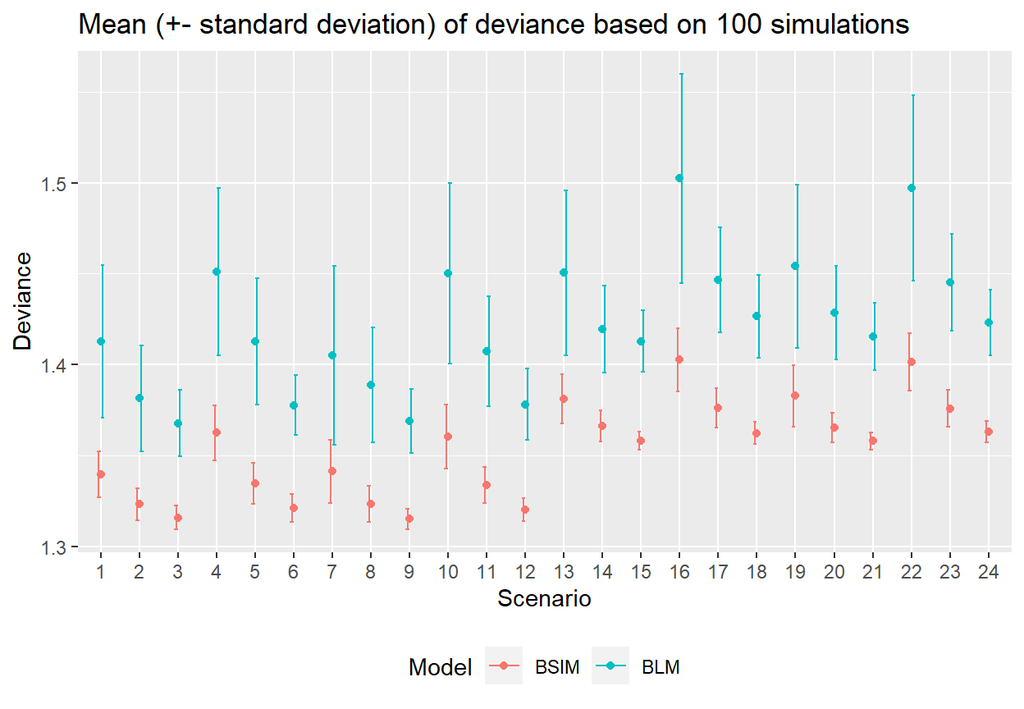

```r
m_dev <- results %>%
  group_by(replicate) %>%
  dplyr::summarise(mean_dev_bsim=mean(bsim.deviance), mean_dev_sng=mean(sng.bayes.deviance),
                   sd_dev_bsim=sd(bsim.deviance), sd_dev_sng=sd(sng.bayes.deviance))

l_dev <- reshape2::melt(m_dev,id=c("replicate"))
sd <- l_dev %>% subset(variable %in% c("sd_dev_sng","sd_dev_bsim"))
colnames(sd) <- c("replicate","variable_sd","value_sd")
mean_dev <- l_dev %>% subset(variable %in% c("mean_dev_bsim","mean_dev_sng"))
plot_dev <- cbind(mean_dev,sd[,-1])

plot_dev$replicate <- as.factor(plot_dev$replicate)

ggplot(plot_dev, aes(x=replicate, y=value, color=variable)) +
  geom_point()+
  geom_errorbar(aes(ymin=value - value_sd, ymax=value + value_sd), width=.2,
                position=position_dodge())+
  labs(title="Mean (+- standard deviation) of deviance based on 100 simulations",
        y = "Deviance", x= "Scenario")+ theme(legend.position="bottom")+
  scale_color_discrete(name = "Model", labels = c("BSIM", "BLM"))
```

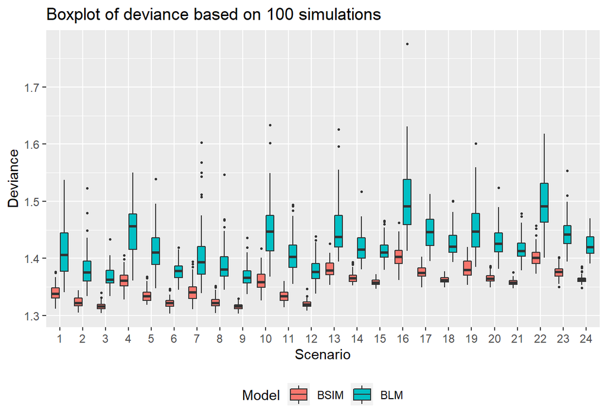

```r
dev <- results[,c("replicate","bsim.deviance","sng.bayes.deviance")]

dev <- reshape2::melt(dev,id=c("replicate"))
dev$replicate <- as.factor(dev$replicate)
ggplot(dev, aes(x=replicate, y=value,fill=variable)) +
  geom_boxplot(outlier.size=0.5)+
  labs(title="Boxplot of deviance based on 100 simulations",
        y = "Deviance", x= "Scenario")+ theme(legend.position="bottom")+
  scale_fill_discrete(name = "Model", labels = c("BSIM", "BLM"))
```

# The expected outcome under the treatment regime

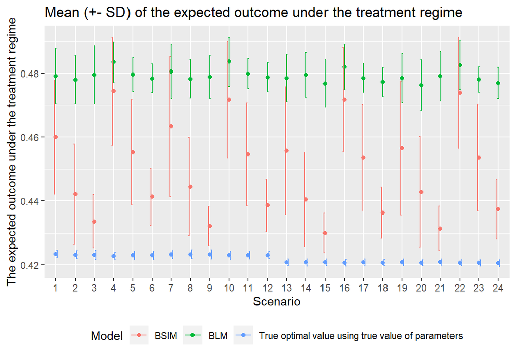

```r
m_e_y <- results %>%
  group_by(replicate) %>%
  dplyr::summarise(mean_y_bsim=mean(bsim.value), mean_y_sng=mean(sng.bayes.value),
                   mean_y_optim = mean(opt.value),
                   sd_y_bsim=sd(bsim.value), sd_y_sng=sd(sng.bayes.value),
                  sd_y_optim = sd(opt.value), )

l_y <- reshape2::melt(m_e_y,id=c("replicate"))
sd <- l_y %>% subset(variable %in% c("sd_y_sng","sd_y_bsim","sd_y_optim"))
colnames(sd) <- c("replicate","variable_sd","value_sd")
mean_y <- l_y %>% subset(variable %in% c("mean_y_bsim","mean_y_sng","mean_y_optim"))
plot_y <- cbind(mean_y,sd[,-1])

plot_y$replicate <- as.factor(plot_y$replicate)

ggplot(plot_y, aes(x=replicate, y=value, color=variable)) +
  geom_point()+
  geom_errorbar(aes(ymin=value - value_sd, ymax=value + value_sd), width=.2,
                position=position_dodge())+
  labs(title="Mean (+- SD) of the expected outcome under the treatment regime",
        y = "The expected outcome under the treatment regime", x= "Scenario")+ theme(legend.position="bottom")+
  scale_color_discrete(name = "Model", labels = c("BSIM", "BLM","True optimal value using true value of parameters"))
```

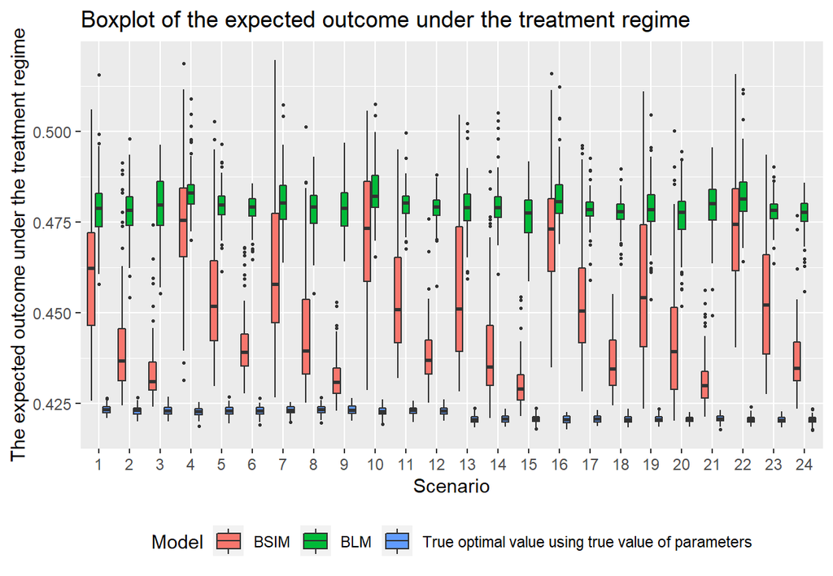

```r
e_y <- results[,c("replicate","bsim.value","sng.bayes.value","opt.value")]

e_y <- reshape2::melt(e_y,id=c("replicate"))
e_y$replicate <- as.factor(e_y$replicate)
ggplot(e_y, aes(x=replicate, y=value,fill=variable)) +
  geom_boxplot(outlier.size=0.5)+
  labs(title="Boxplot of the expected outcome under the treatment regime",
        y = "The expected outcome under the treatment regime", x= "Scenario")+ theme(legend.position="bottom")+
  scale_fill_discrete(name = "Model", labels = c("BSIM", "BLM","True optimal value using true value of parameters"))
```

# PCD

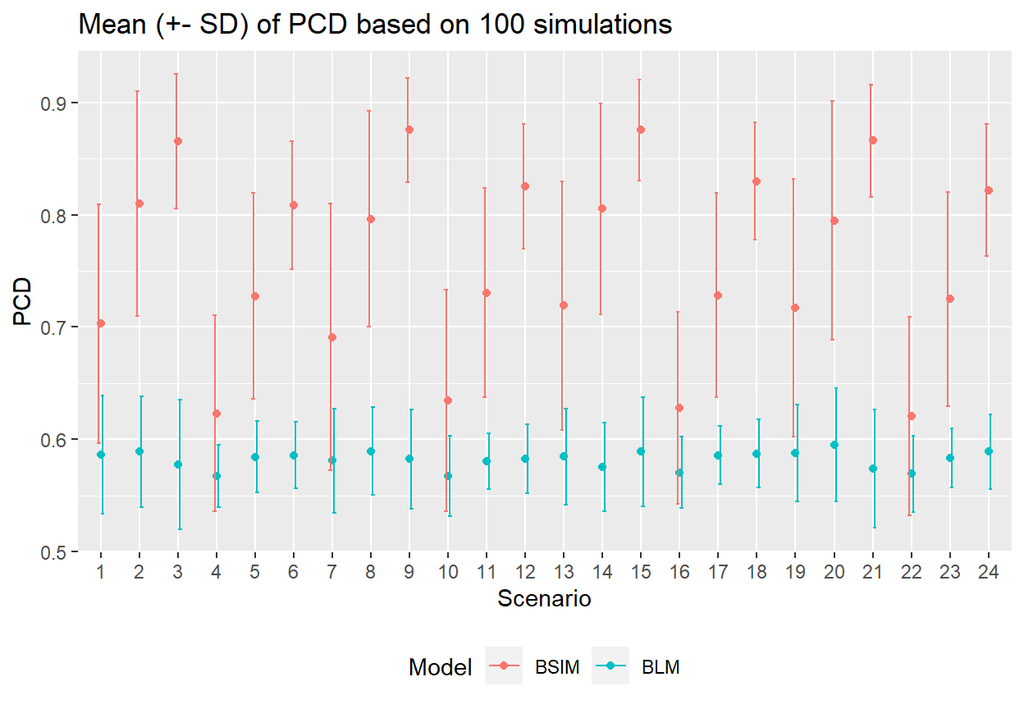

```r
m_pcd <- results %>%
  group_by(replicate) %>%
  dplyr::summarise(mean_pcd_bsim=mean(bsim.accuracy), mean_pcd_sng=mean(sng.bayes.accuracy),
                   sd_pcd_bsim=sd(bsim.accuracy), sd_pcd_sng=sd(sng.bayes.accuracy))

l_pcd <- reshape2::melt(m_pcd,id=c("replicate"))
sd <- l_pcd %>% subset(variable %in% c("sd_pcd_sng","sd_pcd_bsim"))
colnames(sd) <- c("replicate","variable_sd","value_sd")
mean_pcd <- l_pcd %>% subset(variable %in% c("mean_pcd_bsim","mean_pcd_sng"))
plot_pcd <- cbind(mean_pcd,sd[,-1])

plot_pcd$replicate <- as.factor(plot_pcd$replicate)

ggplot(plot_pcd, aes(x=replicate, y=value, color=variable)) +
  geom_point()+
  geom_errorbar(aes(ymin=value - value_sd, ymax=value + value_sd), width=.2,
                position=position_dodge())+
  labs(title="Mean (+- SD) of PCD based on 100 simulations",
        y = "PCD", x= "Scenario")+ theme(legend.position="bottom")+
  scale_color_discrete(name = "Model", labels = c("BSIM", "BLM"))
```

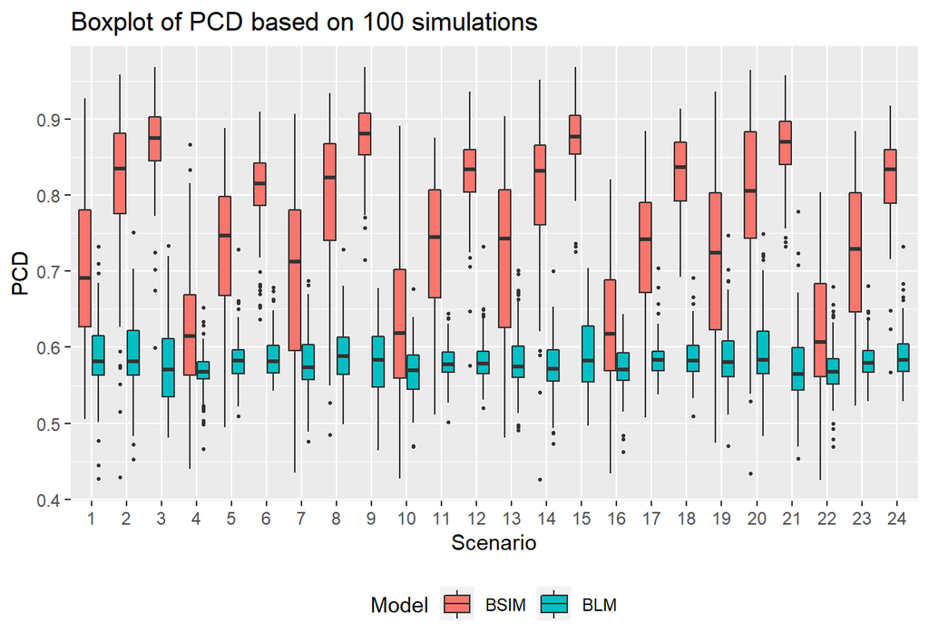

```r
pcd <- results[,c("replicate","bsim.accuracy","sng.bayes.accuracy")]

pcd <- reshape2::melt(pcd,id=c("replicate"))
pcd$replicate <- as.factor(pcd$replicate)
ggplot(pcd, aes(x=replicate, y=value,fill=variable)) +
  geom_boxplot(outlier.size=0.5)+
  labs(title="Boxplot of PCD based on 100 simulations",
        y = "PCD", x= "Scenario")+ theme(legend.position="bottom")+
  scale_fill_discrete(name = "Model", labels = c("BSIM", "BLM"))
```